# Practical Lab 2: Multivariate Linear Regression, Non-Parametric Models and Cross-Validation

### CSCN8010,Sec2 –Foundations of Machine Learning Frameworks

### Name : Shri Vardhan Reddy Tuppari

### Student ID : 8986401

## Objective: Predict the risk of diabetes progression

### Models covered:

1. Univariate polynomial regression models
2. Multivariate Polynomial models
3. Decision Trees
4. KNNs

# Part 1: Data loading, exploration, and preprocessing

## 1: Load the Dataset

The Diabetes dataset from Scikit-Learn is loaded, which contains various physiological variables and their relation to the progression of diabetes one year after baseline.

```python
from sklearn import datasets
import pandas as pd

# Load the diabetes dataset
diabetes_data = datasets.load_diabetes(as_frame=True)
df = diabetes_data.frame

# Check the data
df.head()
```

|  | age | sex | bmi | bp | s1 | s2 | s3 | s4 | s5 | s6 | target |
| --- | --- | --- | --- | --- | --- | --- | --- | --- | --- | --- | --- |
| 0 | 0.038076 | 0.050680 | 0.061696 | 0.021872 | -0.044223 | -0.034821 | -0.043401 | -0.002592 | 0.019907 | -0.017646 | 151.0 |
| 1 | -0.001882 | -0.044642 | -0.051474 | -0.026328 | -0.008449 | -0.019163 | 0.074412 | -0.039493 | -0.068332 | -0.092204 | 75.0 |
| 2 | 0.085299 | 0.050680 | 0.044451 | -0.005670 | -0.045599 | -0.034194 | -0.032356 | -0.002592 | 0.002861 | -0.025930 | 141.0 |
| 3 | -0.089063 | -0.044642 | -0.011595 | -0.036656 | 0.012191 | 0.024991 | -0.036038 | 0.034309 | 0.022688 | -0.009362 | 206.0 |
| 4 | 0.005383 | -0.044642 | -0.036385 | 0.021872 | 0.003935 | 0.015596 | 0.008142 | -0.002592 | -0.031988 | -0.046641 | 135.0 |

## 2: Framing the problem

The goal of this lab is to predict the "disease progression one year after baseline" based on other features in the dataset. The target variable is 'disease progression', and the other features include age, sex, BMI, blood pressure, etc.

## 3: Exploratory Data Analysis (EDA)

In this step, we will describe the dataset, visualize the distributions of features, and analyze the relationships between features and the target variable.

### Code:

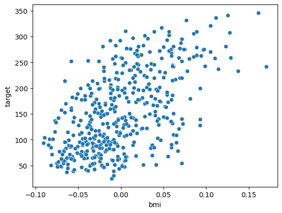

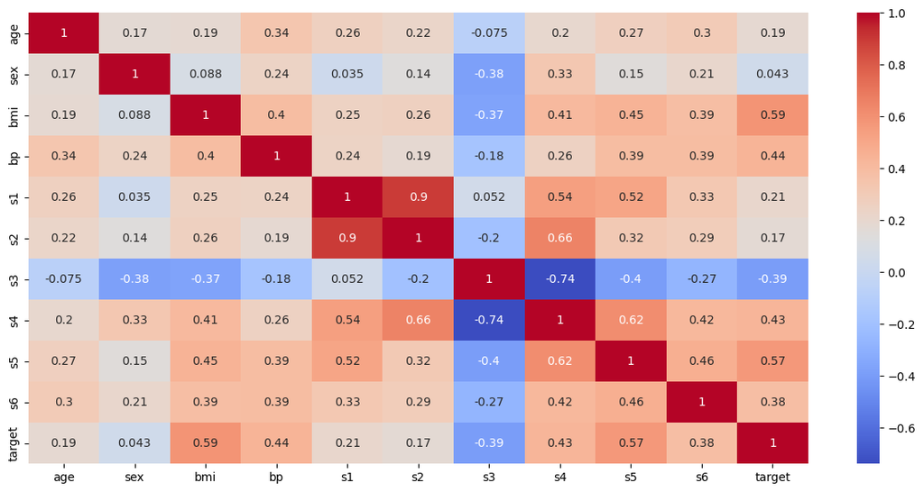

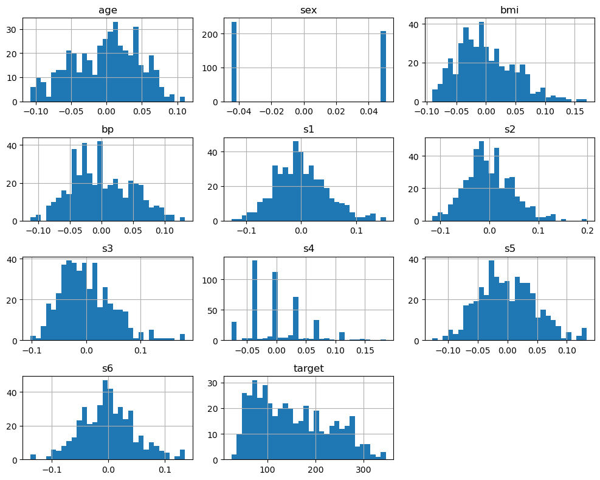

```python
import seaborn as sns
import matplotlib.pyplot as plt

# Statistics
df.describe()

# Scatter Plot for BMI vs Disease Progression
sns.scatterplot(data=df, x='bmi', y='target')

# Correlation Matrix
plt.figure(figsize=(15, 7))
sns.heatmap(df.corr(), annot=True, cmap='coolwarm')
plt.show()

# Histograms
df.hist(bins=30, figsize=(10, 8))
plt.tight_layout()
plt.show()
```